# Graficacion para Data Science

En este Notebook te mostrare como clasificar adecuadamente tus variables de un conjunto de datos y como de acuerdo a su clasificación generar gráficas útiles y facil de interpretar.

## Datos

En este Tutorial trabajaremos con dos fuentes de datos  
- Pacientes examinados con diabetes https://raw.githubusercontent.com/Cruzalirio/Ucentral/master/Bases/Diabetes.csv  
- Pacientes examinados por cancer https://raw.githubusercontent.com/Cruzalirio/Ucentral/master/Bases/Cancer.csv

## Tipos de variables

Las variables se clasifican en principio en dos clases  
- **Cualitativas** Son variables que representan una cualidad, e.g Estrato, Sexo  
- **Cuantitativas** Son variables numéricas con los cuales tiene sentido sumar o restar

**Nota:** Es posible convertir a veces entre variables cualitativas a cuantitativas, y SIEMPRE es posible pasar de cuantitaticas a cualitativas.

**Ejemplo:** Las estrellas que podemos ver en las calificaciones de usuarios en Google Maps es una variable cualitativa pero se convierte a cuantitativa y de hecho es posible operar con ella, en este caso el mismo sitio web nos calcula el promedio.

### Cualitativas

Las variables cualitativas pueden ser clasificadas a su vez en dos clases.  
- **Nominales:** NO pueden ordenarse  
- **Ordinales:** Sus datos se pueden ordenar

**Nota:** No se vale el orden alfanumérico

### Cuantitativas

Las variables cuantitativas pueden ser clasificadas a su vez en dos clases.  
- **Discretas:** Variables que toman varoles en un conjunto discreto.  
- **Continuas:** No sn discretas, tienen decimales.

Adicionalmente, existe otra manera de clasificar las variables cuantitativas.  
- **Intervalo:** No tienen cero absoluto, es decir el cero no implica la no existencia de valor. E.g, Temperatura, Calificación,Edad medida en años cumplidos.  
- **Razón:** Tienen cero absoluto, es decir que el cero implica que no existe valor. E.g, Altura, Masa, Edad, # de hijos.

## Análisis sobre la variable de Genero en los datos de diabetes.

La variable de genero según los tipos definidos arriba corresponde a una variable, de tipo cualitativa, nominal. Es decir, es una variable que representa una cualidad del paciente y además no es posible darle un orden a esta variabl, no existe una medida superior o inferior que la otra.

Antes de cualquier gráfica se debe hacer una tabla de frecuencias, (En los lenguajes de programacion modernos como python o R, ya es posible ahorrarse este paso y pasar a graficar, el mismo software las crea y grafica con base en ellas)

| Age | Gender | Polyuria | Polydipsia | sudden.weight.loss | weakness | Polyphagia | Genital.thrush | visual.blurring | Itching | Irritability | delayed.healing | partial.paresis | muscle.stiffness | Alopecia | Obesity | class |
| --- | --- | --- | --- | --- | --- | --- | --- | --- | --- | --- | --- | --- | --- | --- | --- | --- |
| 40 | Male | No | Yes | No | Yes | No | No | No | Yes | No | Yes | No | Yes | Yes | Yes | Positive |
| 58 | Male | No | No | No | Yes | No | No | Yes | No | No | No | Yes | No | Yes | No | Positive |
| 41 | Male | Yes | No | No | Yes | Yes | No | No | Yes | No | Yes | No | Yes | Yes | No | Positive |
| 45 | Male | No | No | Yes | Yes | Yes | Yes | No | Yes | No | Yes | No | No | No | No | Positive |
| 60 | Male | Yes | Yes | Yes | Yes | Yes | No | Yes | Yes | Yes | Yes | Yes | Yes | Yes | Yes | Positive |
| 55 | Male | Yes | Yes | No | Yes | Yes | No | Yes | Yes | No | Yes | No | Yes | Yes | Yes | Positive |
| 57 | Male | Yes | Yes | No | Yes | Yes | Yes | No | No | No | Yes | Yes | No | No | No | Positive |
| 66 | Male | Yes | Yes | Yes | Yes | No | No | Yes | Yes | Yes | No | Yes | Yes | No | No | Positive |
| 67 | Male | Yes | Yes | No | Yes | Yes | Yes | No | Yes | Yes | No | Yes | Yes | No | Yes | Positive |
| 70 | Male | No | Yes | Yes | Yes | Yes | No | Yes | Yes | Yes | No | No | No | Yes | No | Positive |

[output cut: 510 more lines]

| Gender | FrecAbs |
| --- | --- |
| Female | 192 |
| Male | 328 |

Podemos observar que existen las pacientes masculinos que femeninos en el conjunto de datos. ¿Es posible ver en que proporcion es mas grande?, es decir en terminos porcentuales.

| Gender | FrecRel |
| --- | --- |
| Female | 36.92 |
| Male | 63.08 |

Esta tabla se denomina tabla de frecuencias relativas.

Con esta tabla podemos genera un gráfico bastante útil, gráfico de torta, porque la suma del porcentaje femenino y masculino representan el 100% y son pocas clases, lo cual lo hace facil de entender e interpretar.

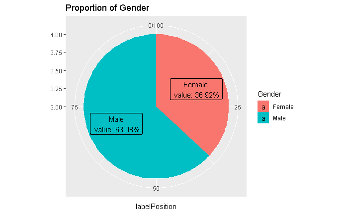

```r
# Compute the cumulative percentages (top of each rectangle)
FrecRel_Table$ymax = cumsum(FrecRel_Table$FrecRel)

# Compute the bottom of each rectangle
FrecRel_Table$ymin = c(0, head(FrecRel_Table$ymax, n=-1))

# Compute label position
FrecRel_Table$labelPosition <- (FrecRel_Table$ymax + FrecRel_Table$ymin) / 2

# Compute a good label
FrecRel_Table$label <- paste0(FrecRel_Table$Gender, "\n value: ", FrecRel_Table$FrecRel, "%")

## Gráfico de pastel
ggplot(data=FrecRel_Table, mapping = aes(ymax=ymax, ymin=ymin, xmax=4, xmin=3, fill=Gender)) +
  geom_rect() +
  coord_polar(theta = "y") +
  geom_label( x=3.6, aes(y=labelPosition, label=label), size=4) +
  ggtitle("Proportion of Gender")
```

Las tablas de frecuencia pueden complementarse con dos columnas adicionales **Frecuencia Absoluta Acumulada** y **Frecuencia Relativa Acumulada**, solo deben utilizarse para variables cualitativas que sean ordinales y no tiene sentido sumarlas en un total.

En este tipo son más útiles las variables de barras o circulares.

## Análisis sobre la variable de Edad en los datos de diabetes.

Esta variable es de tipo Cuantitativa, discreta de Intervalo. porque tener 0 años no representa ausencia de edad. Esto debido a que se mide la edad en número de años cumplidos, un bebe con 6 meses de edad tendra cero años pero no significa que no tenga edad.

En esta grafica debemos evaluar cuantas diferentes edades estan registradas.

```r
length(unique(datosDiabetes$Age))
```

```
[1] 51
```

Para el caso de la edad, podemos evaluar cuantos serian los grupos recomendados por la regla de sturges.

```r
gruposSturges
```

```
[1] 6.672425
```

Seis clases es facil de interpretar. Para crear la gráfica debemos calcular el rango (diferencia entre el valor maximo y minimo de una variable cuantitativa)

```r
rangoEdad
```

```
[1] 74
```

Con este valor podemos saber como separar cada grupo

```r
delta
```

```
[1] 12.33333
```

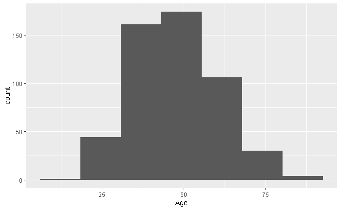